# Assignment_10

### Portfolio assignment 10

15 min: Perform a bivariate analysis (Pearson correlation and scatter plot) on at least 1 combination of 2 columns with numeric data in the dataset that you chose in portfolio assignment 4. Does the correlation and scatter plot match your expectations? Add your answer to your notebook. Commit the Notebook to your portfolio when you're finished.

```python
import pandas as pd
```

```python
Pokemon = pd.read_csv("Pokemon.csv", sep=";")
```

```python
Pokemon.head()
```

|  | abilities | attack | capture_rate | classfication | defense | experience_growth | height_m | hp | name | percentage_male | pokedex_number | sp_attack | sp_defense | speed | type1 | type2 | weight_kg | generation | is_legendary |
| --- | --- | --- | --- | --- | --- | --- | --- | --- | --- | --- | --- | --- | --- | --- | --- | --- | --- | --- | --- |
| 0 | ['Rock Head', 'Sturdy', 'Sand Veil', 'Magnet P... | 80 | 255.0 | Rock Pokémon | 100 | 1059860 | 0 | 40 | Geodude | 50 | 74 | 30 | 30 | 20 | rock | ground | 0 | 1 | 0 |
| 1 | ['Stench', 'Sticky Hold', 'Poison Touch', 'Poi... | 80 | 190.0 | Sludge Pokémon | 50 | 1000000 | 0 | 80 | Grimer | 50 | 88 | 40 | 50 | 25 | poison | poison | 0 | 1 | 0 |
| 2 | ['Rock Head', 'Sturdy', 'Sand Veil', 'Magnet P... | 95 | 120.0 | Rock Pokémon | 115 | 1059860 | 0 | 55 | Graveler | 50 | 75 | 45 | 45 | 35 | rock | ground | 0 | 1 | 0 |
| 3 | ['Sand Veil', 'Sand Rush', 'Snow Cloak', 'Slus... | 75 | 255.0 | Mouse Pokémon | 90 | 1000000 | 0 | 50 | Sandshrew | 50 | 27 | 10 | 35 | 40 | ground | ice | 0 | 1 | 0 |
| 4 | ['Chlorophyll', 'Harvest', 'Frisk', 'Harvest'] | 105 | 45.0 | Coconut Pokémon | 85 | 1250000 | 0 | 95 | Exeggutor | 50 | 103 | 125 | 75 | 45 | grass | psychic | 0 | 1 | 0 |

```python
pokemonCorrelations = Pokemon.corr()
pokemonCorrelations.style.background_gradient(cmap='coolwarm', axis=None).format(precision=2)
```

|  | attack | capture_rate | defense | experience_growth | height_m | hp | percentage_male | pokedex_number | sp_attack | sp_defense | speed | weight_kg | generation | is_legendary |
| --- | --- | --- | --- | --- | --- | --- | --- | --- | --- | --- | --- | --- | --- | --- |
| attack | 1.00 | -0.50 | 0.47 | 0.24 | 0.41 | 0.41 | 0.01 | 0.14 | 0.37 | 0.27 | 0.35 | 0.37 | 0.10 | 0.30 |
| capture_rate | -0.50 | 1.00 | -0.45 | -0.17 | -0.38 | -0.48 | -0.21 | -0.09 | -0.52 | -0.52 | -0.38 | -0.33 | -0.05 | -0.33 |
| defense | 0.47 | -0.45 | 1.00 | 0.13 | 0.35 | 0.24 | -0.06 | 0.10 | 0.24 | 0.53 | 0.01 | 0.42 | 0.06 | 0.27 |
| experience_growth | 0.24 | -0.17 | 0.13 | 1.00 | 0.25 | 0.21 | -0.12 | 0.08 | 0.20 | 0.09 | 0.14 | 0.25 | 0.05 | 0.36 |
| height_m | 0.41 | -0.38 | 0.35 | 0.25 | 1.00 | 0.47 | -0.05 | 0.04 | 0.35 | 0.32 | 0.19 | 0.63 | 0.01 | 0.32 |
| hp | 0.41 | -0.48 | 0.24 | 0.21 | 0.47 | 1.00 | -0.04 | 0.11 | 0.37 | 0.37 | 0.16 | 0.43 | 0.07 | 0.31 |
| percentage_male | 0.01 | -0.21 | -0.06 | -0.12 | -0.05 | -0.04 | 1.00 | -0.07 | 0.06 | -0.03 | -0.00 | -0.07 | -0.02 | -0.18 |
| pokedex_number | 0.14 | -0.09 | 0.10 | 0.08 | 0.04 | 0.11 | -0.07 | 1.00 | 0.11 | 0.09 | 0.00 | 0.14 | 0.99 | 0.20 |
| sp_attack | 0.37 | -0.52 | 0.24 | 0.20 | 0.35 | 0.37 | 0.06 | 0.11 | 1.00 | 0.51 | 0.44 | 0.25 | 0.07 | 0.41 |
| sp_defense | 0.27 | -0.52 | 0.53 | 0.09 | 0.32 | 0.37 | -0.03 | 0.09 | 0.51 | 1.00 | 0.23 | 0.30 | 0.05 | 0.34 |
| speed | 0.35 | -0.38 | 0.01 | 0.14 | 0.19 | 0.16 | -0.00 | 0.00 | 0.44 | 0.23 | 1.00 | 0.05 | -0.02 | 0.31 |
| weight_kg | 0.37 | -0.33 | 0.42 | 0.25 | 0.63 | 0.43 | -0.07 | 0.14 | 0.25 | 0.30 | 0.05 | 1.00 | 0.10 | 0.39 |
| generation | 0.10 | -0.05 | 0.06 | 0.05 | 0.01 | 0.07 | -0.02 | 0.99 | 0.07 | 0.05 | -0.02 | 0.10 | 1.00 | 0.14 |
| is_legendary | 0.30 | -0.33 | 0.27 | 0.36 | 0.32 | 0.31 | -0.18 | 0.20 | 0.41 | 0.34 | 0.31 | 0.39 | 0.14 | 1.00 |

### De statistiek Special Defense (Sp. Def) bepaalt hoe goed een Pokémon zich kan verdedigen tegen speciale bewegingen. Als de normale Defense statestiek hoog is zal de Defense statestiek tegen speciale aanvallen ook hoog zijn. Ik verwacht dat hier een goede correlatie in te zien is.

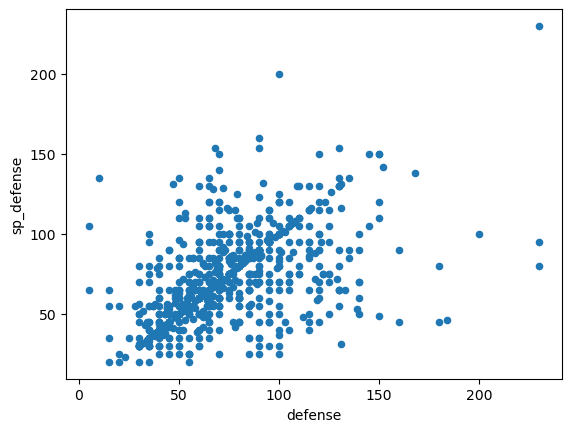

```python
Pokemon.plot(kind='scatter', x='defense', y='sp_defense')
```

### Als het gewicht van een pokemon hoog is, verwacht ik dat zijn snelheid laag zal zijn. Ik verwacht dat hier goede correlatie te zien zal zijn.

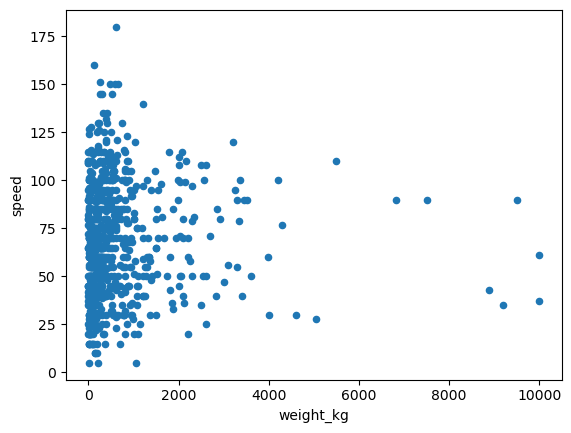

```python
Pokemon.plot(kind='scatter', x='weight_kg', y='speed')
```